# main_light_levels

## Summary of Light Levels data

### Installed the required packages

- Installed the required packages and also importing the functions required from other python files

```python
import logging
import pandas as pd
import os
from os import listdir
from os.path import isfile, join
import sys
from os import environ
from IPython import embed
import numpy as np
import matplotlib.pyplot as plt
import plotly.express as px

from data_loading import data_loading, dataframe_columns_check
from data_cleaning import column_renaming, removing_duplicates, removing_missing_values
from helpers import data_summary
```

### Reading the raw data

- Have passed the location of the raw data as a environment variable

```python
# Path of the uploaded json file
path = environ['light_levels']

# Loading the data and assigning a name to the dataframe
light_levels = data_loading(path)
light_levels.name = 'light_levels'
```

### Checking if the required set of columns are present in the raw data

```python
# Columns which are required in the uploaded data
required_columns = ['Date', 'Light Score ']

# checking the required set of columns are present in the uploaded file
if dataframe_columns_check(light_levels, required_columns):
    print ("Columns in raw data:", list(light_levels.columns))
    print ("\nRequired columns:", required_columns)
    print ("\nCheck: The uploaded data has the required set of columns")
else:
    print ("Check: The uploaded data does not have the required set of columns")
```

```
Columns in raw data: ['Date', 'Light Score ']

Required columns: ['Date', 'Light Score ']

Check: The uploaded data has the required set of columns
```

### Renaming the columns as required

```python
print("Columns in raw data: ", list(light_levels.columns))
light_levels = column_renaming(light_levels, required=True)
print("\nColumns in processed data: ", list(light_levels.columns))
```

```
Columns in raw data:  ['Date', 'Light Score ']

Columns in processed data:  ['Date', 'Light Score ']
```

### Removing the duplicate rows in the data

- We have observed here that the same date has been assigned for multiple slight scores
- Since there is no further information about it, we have taken only the first instance of the date occurance

```python
print("Row count in the raw data: ", light_levels.shape[0])
light_levels = removing_duplicates(light_levels)
print("Row count after removing duplicates: ", light_levels.shape[0])
```

```
Row count in the raw data:  3251
Row count after removing duplicates:  3063
```

### MIssing values treatment

```python
print("Row count in the raw data: ", light_levels.shape[0])
light_levels = removing_missing_values(light_levels)
print("Row count after removing rows with missing values: ", light_levels.shape[0])
```

```
Row count in the raw data:  3063
Row count after removing rows with missing values:  3055
```

### Data exploration analysis

#### Basic data description

```python
data_summary(light_levels)
```

```
Dataframe name  : light_levels

Rows     :  3055
Columns  :  2

Features :
 ['Date', 'Light Score ']

Missing values in each column:   [0, 0]

Unique values :
 Date            3055
Light Score       15
dtype: int64


 ######################################
```

```python
# Anaysing the column data type
light_levels.info()
```

```
<class 'pandas.core.frame.DataFrame'>
Int64Index: 3055 entries, 0 to 3250
Data columns (total 2 columns):
Date            3055 non-null datetime64[ns]
Light Score     3055 non-null float64
dtypes: datetime64[ns](1), float64(1)
memory usage: 71.6 KB
```

#### Analysing the frequency of each light score

- If we categorize the score into 3 buckets, [Low, Medium, High], we can observe that the occurance of the Low ad High buckets is comparitively higher than the Medium bucket

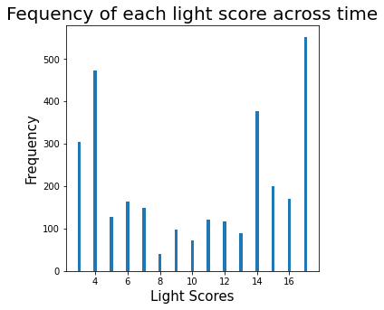

```python
locality_toll = light_levels[['Light Score ']].pivot_table(index = ['Light Score '], aggfunc ='size').reset_index().sort_values(0, ascending=False)
locality_toll.columns = ['Light Score ', 'Frequency']
locality_toll.head()

locality = locality_toll['Light Score '].values.tolist()
toll = locality_toll['Frequency'].values.tolist()

fig = plt.figure(figsize = (5, 5))

# creating the bar plot
plt.bar(locality, toll, width = 0.2)

plt.xlabel("Light Scores", fontsize=15)
plt.ylabel("Frequency", fontsize=15)
# plt.set_title('Title', pad=20)
plt.title("Fequency of each light score across time", fontsize=20)
plt.show()
```

#### Analysing the mean light score over the years

- The mean light scores during the period 2000 to 2008 are very high compared to the period after that.
- But, after the steep fall between 2008 and 2009, we can observe a steady increase in the scores

```python
light_levels['Date_year'] = light_levels['Date'].dt.strftime('%Y')
date_toll = light_levels.pivot_table(index = ['Date_year'], aggfunc ='mean').reset_index().sort_values('Date_year', ascending=False)
date_toll.columns = ['Date_year', 'mean_score']
date_toll.head()

fig = px.line(date_toll, x='Date_year', y='mean_score',
              labels={
                     "Date_year": "Year",
                     "mean_score": "Mean light score",
                 },
              title="Mean light scores trend by year")
fig.update_layout(title=dict(
                    x=0.5,
                    y=0.9,
                    font=dict(
                    family="Arial",
                    size=20,
                    color='#000000'
                    )))
fig.show()
```

[interactive chart not shown]

#### Analysing the mean light score over the months

- We can observe that the during the winter months, there is a significant higher average of the light scores
- This could probably be attributed to the shorter days during these months

```python
light_levels['Date_month'] = light_levels['Date'].dt.month
date_toll = light_levels.pivot_table(index = ['Date_month'], aggfunc ='mean').reset_index().sort_values('Date_month', ascending=False)
date_toll.columns = ['Date_month', 'mean_score']
date_toll.head()

fig = px.line(date_toll, x='Date_month', y='mean_score',
              labels={
                     "Date_month": "Months",
                     "mean_score": "Mean light score",
                 },
              title="Mean light scores trend by month")
fig.update_layout(title=dict(
                    x=0.5,
                    y=0.9,
                    font=dict(
                    family="Arial",
                    size=20,
                    color='#000000'
                    )))
fig.show()
```

[interactive chart not shown]

### Saving the processed data

```python
csv_files_address = "/home/sahit/Documents/MLE_opportunities_with_Tiger_Analytics/simple_dj_docker/media/CSV_files/"
file_name = os.path.join(csv_files_address,os.path.basename(path).split('.')[0])
light_levels.to_csv(file_name+'.csv', index=False)
```